# SI 630: Homework 1 - Classification (Sangho Eum)

## TASK 1: Naive Bayes Classifier

# Conclusion

### Part 1 Conclusion

- What happens as you change the value of smoothing alpha? Include a plot of your classifier’s performance on the development data where (i) your model’s performance is on the y-axis and (ii) the choice in smoothing alpha is on the x-axis. Note that most people use α = 1; does this value give good performance for you?

-> I have the best performance with 0.3. After 0.3, the performance is getting decreased a liitle bit. -> Graphs are below.

- Submit your best model’s predictions on the test data to Kaggle.

### Part 2 Conclustion

- Write a better tokenizing function called better tokenize that fixes these issues. In your report, describe which kinds of errors you fixed, what kind of features you included, and why you made the choices you did.

-> I remove emoji and stop_words because I think they are neutral words which mean they do not affect positivity or negativity.

- Recompute your performance on the development data using the better tokenize method. Describe in your report what impact this had on the performance.

### Part 1

```python
# import library
import csv
import math
import re
from sklearn.metrics import f1_score
import matplotlib.pyplot as plt
```

```python
# Load data sets
dat = []
dev = []

with open('train.tsv') as tsvfile:
  reader = csv.DictReader(tsvfile, dialect='excel-tab', quoting=csv.QUOTE_NONE)
  for i in reader:
      dat.append(i)

with open('dev.tsv') as tsvfile:
  reader2 = csv.DictReader(tsvfile, dialect='excel-tab', quoting=csv.QUOTE_NONE)
  for i in reader2:
      dev.append(i)
```

```python
# Write tokenize and better_tokenize functions

stop_words = []

with open('stopwords.txt', 'r') as file:
    for line in file.readlines():
        stop_words.append(line.strip())


def tokenize(review):
    return review.split()

def better_tokenize(text):
    text = text.lower()
    text = re.sub(r"(@[a-zA-Z0-9_]+)|(\w+:\/\/\S+)", " ", text)
    text = re.sub('[^A-Za-z0-9 ]+', '', text)
    features = text.split()
    filtered_features = []
    for feature in features:
        if feature not in stop_words:
            filtered_features.append(feature)
    return filtered_features
```

```python
# Write train fuction using tokenize function

def train(data, alpha = 0):
    dct_xi_0 = {}
    dct_xi_1 = {}
    dct_pxi_0 = {}
    dct_pxi_1 = {}
    pos_tot = 0
    neg_tot = 0

    for i in data:
        if i['class'] == '0':
            pos_tot += len(tokenize(i['text']))
            for k in tokenize(i['text']):
                dct_xi_0[k] = dct_xi_0.get(k,0) + 1
        else:
            for k in tokenize(i['text']):
                dct_xi_1[k] = dct_xi_1.get(k,0) + 1
            neg_tot += len(tokenize(i['text']))

    tot = pos_tot + neg_tot
    py0 = pos_tot / tot
    py1 = neg_tot / tot
    words = set(list(dct_xi_0.keys()) + list(dct_xi_1.keys()))
    v = len(words)

    for i in words:
        dct_pxi_0[i] = (dct_xi_0.get(i, 0) + alpha) / (pos_tot+v * alpha)
        dct_pxi_1[i] = (dct_xi_1.get(i, 0) + alpha) / (neg_tot+v * alpha)

    dct_tot = {'py0': py0, 'py1':py1, 'pxi_0':dct_pxi_0,'pxi_1':dct_pxi_1, 'words_set':words}
    return dct_tot
```

```python
# Write classify function using tokenize function

def classify(words, dct_tot, alpha = 0):
    w = tokenize(words)
    words_set = dct_tot['words_set']
    py0 = dct_tot['py0']
    py1 = dct_tot['py1']
    pxi_0 = dct_tot['pxi_0']
    pxi_1 = dct_tot['pxi_1']
    pos = 1
    neg = 1
    for i in w:
        if i not in words_set :
            continue
        pos = pos * pxi_0[i]
        neg = neg * pxi_1[i]
    if alpha == 0:
        py0_x = pos * py0
        py1_x = neg * py1
        if py0_x >= py1_x:
            return 0
        else:
            return 1
    else:
        py0_x = math.log10(pos * py0)
        py1_x = math.log10(neg * py1)
        if py0_x >= py1_x:
            return 0
        else:
            return 1
```

```python
# Write f1_check function that returns performance with tokenize function

def f1_check(deve, data, alpha):
    y_pred = []
    y_true = []
    dct = train(data, alpha)
    for i in deve:
        y_pred.append(classify(i['text'], dct, alpha))
        y_true.append(int(i['class']))
    F1 = f1_score(y_true, y_pred)
    return F1
```

#### Result with tokenize function

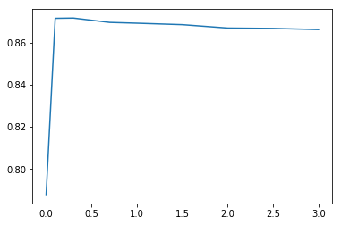

```python
# Print plot
alp_list = [0, 0.1, 0.3, 0.7, 1, 1.5, 2, 2.5, 3]
per_list = []

for i in alp_list:
    per_list.append(f1_check(dev, dat, i))
plt.plot(alp_list, per_list)
plt.show()
```

```python
# Print alphas and performances
print(alp_list)
print(per_list)
```

```
[0, 0.1, 0.3, 0.7, 1, 1.5, 2, 2.5, 3]
[0.7878060489678349, 0.87162750217580487, 0.87175043327556334, 0.86967797709098771, 0.8693022251026139, 0.8686084142394821, 0.86699719767191197, 0.86681034482758623, 0.86626402070750652]
```

### Part 2

```python
# Write train2 function with better_tokenize function

def train2(data, alpha = 0):
    dct_xi_0 = {}
    dct_xi_1 = {}
    dct_pxi_0 = {}
    dct_pxi_1 = {}
    pos_tot = 0
    neg_tot = 0

    for i in data:
        if i['class'] == '0':
            pos_tot += len(better_tokenize(i['text']))
            for k in better_tokenize(i['text']):
                dct_xi_0[k] = dct_xi_0.get(k,0) + 1
        else:
            for k in better_tokenize(i['text']):
                dct_xi_1[k] = dct_xi_1.get(k,0) + 1
            neg_tot += len(better_tokenize(i['text']))

    tot = pos_tot + neg_tot
    py0 = pos_tot / tot
    py1 = neg_tot / tot
    words = set(list(dct_xi_0.keys()) + list(dct_xi_1.keys()))
    v = len(words)

    for i in words:
        dct_pxi_0[i] = (dct_xi_0.get(i, 0) + alpha) / (pos_tot+v * alpha)
        dct_pxi_1[i] = (dct_xi_1.get(i, 0) + alpha) / (neg_tot+v * alpha)

    dct_tot = {'py0': py0, 'py1':py1, 'pxi_0':dct_pxi_0,'pxi_1':dct_pxi_1, 'words_set':words}
    return dct_tot
```

```python
# Write classify2 function using better_tokenize function

def classify2(words, dct_tot, alpha = 0):
    w = better_tokenize(words)
    words_set = dct_tot['words_set']
    py0 = dct_tot['py0']
    py1 = dct_tot['py1']
    pxi_0 = dct_tot['pxi_0']
    pxi_1 = dct_tot['pxi_1']
    pos = 1
    neg = 1
    for i in w:
        if i not in words_set :
            continue
        pos = pos * pxi_0[i]
        neg = neg * pxi_1[i]
    if alpha == 0:
        py0_x = pos * py0
        py1_x = neg * py1
        if py0_x >= py1_x:
            return 0
        else:
            return 1
    else:
        py0_x = math.log10(pos * py0)
        py1_x = math.log10(neg * py1)
        if py0_x >= py1_x:
            return 0
        else:
            return 1
```

```python
# Write f1_check function that returns performance with better_tokenize function

def f1_check2(deve, data, alpha):
    y_pred = []
    y_true = []
    dct = train2(data, alpha)
    for i in deve:
        y_pred.append(classify2(i['text'], dct, alpha))
        y_true.append(int(i['class']))
    F1 = f1_score(y_true, y_pred)
    return F1
```

#### Result with better_tokenize function

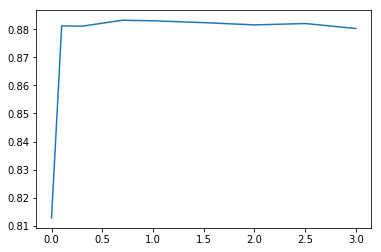

```python
# Print plot
alp_list = [0, 0.1, 0.3, 0.7, 1, 1.5, 2, 2.5, 3]
per_list2 = []

for i in alp_list:
    per_list2.append(f1_check2(dev, dat, i))
plt.plot(alp_list, per_list2)
plt.show()
```

```python
# Print alphas and performances
print(alp_list)
print(per_list2)
```

```
[0, 0.1, 0.3, 0.7, 1, 1.5, 2, 2.5, 3]
[0.81276396058188649, 0.88123620309050765, 0.88112502746649091, 0.88324205914567355, 0.88304862023653086, 0.8823914466506656, 0.88158467566390941, 0.88207136640557016, 0.88029545948294607]
```

#### Create kaggle.csv for kaggle submission

```python
testarr = []
y_instanceids = []
y_pred = []
traindic = train2(dat, 1)

with open('test.unlabeled.tsv') as tsvfile:
    reader3 = csv.DictReader(tsvfile, dialect='excel-tab', quoting=csv.QUOTE_NONE)
    for i in reader3:
        testarr.append(i)

csvfile = open("kaggle.csv", 'w')

testarr =[]

for i in testarr:
    y_instanceids.append(i['instance_id'])
    y_pred.append(classify2(i['text'], traindic, 1))


with csvfile:
    titlerow = ['instance_id', 'class']
    writer = csv.writer(csvfile)
    writer.writerow(titlerow)

    for i in range(len(y_instanceids)):
        writer.writerow([y_instanceids[i], y_pred[i]])
```